# Final-0070150

```python
import pandas as pd
pd.options.display.max_colwidth = 500
```

1- How many lines are there in the dataframe? How much space does it consume in your memory?

```python
df = pd.read_csv("202005171549_corona_tweets.csv")
```

```python
print('number of lines in the dataframe: {}'.format(len(df)))
```

```
number of lines in the dataframe: 541793
```

```python
# memory usage
df.info(memory_usage='deep')
```

```
<class 'pandas.core.frame.DataFrame'>
RangeIndex: 541793 entries, 0 to 541792
Data columns (total 20 columns):
 #   Column               Non-Null Count   Dtype
---  ------               --------------   -----
 0   Unnamed: 0           541793 non-null  int64
 1   Unnamed: 0.1         541793 non-null  int64
 2   coordinates          74 non-null      object
 3   country              1900 non-null    object
 4   created_at           541793 non-null  object
 5   device               541793 non-null  object
 6   entity_hashtags      541793 non-null  object
 7   entity_mentions      541793 non-null  object
 8   entity_type          20792 non-null   object
 9   entity_urls          541793 non-null  object
 10  id_str               541793 non-null  int64
 11  in_reply_to_user_id  24382 non-null   float64
 12  is_retweet           541793 non-null  bool
 13  screen_name          541793 non-null  object
 14  text                 541793 non-null  object
 15  tweet_location       1902 non-null    object
 16  user_followers       541793 non-null  int64
 17  user_following       541793 non-null  int64
 18  user_id              541793 non-null  int64
 19  user_location        367568 non-null  object
dtypes: bool(1), float64(1), int64(6), object(12)
memory usage: 523.2 MB
```

2- What are the column names?

```python
print('Column names are as follows')
list(df.columns)
```

```
Column names are as follows
```

```
['Unnamed: 0',
 'Unnamed: 0.1',
 'coordinates',
 'country',
 'created_at',
 'device',
 'entity_hashtags',
 'entity_mentions',
 'entity_type',
 'entity_urls',
 'id_str',
 'in_reply_to_user_id',
 'is_retweet',
 'screen_name',
 'text',
 'tweet_location',
 'user_followers',
 'user_following',
 'user_id',
 'user_location']
```

3- Identify the most tweeting 50 users. The value_counts() method will help you

```python
print('Most tweeting 50 users:')
df.screen_name.value_counts()[:50]
```

```
Most tweeting 50 users:
```

```
FluTrackers        312
s_akrati           309
the_paper_link     275
LarryBoorstein     265
BearingTruth       242
ORoomLeb           179
DoobiestB          145
GertvanderHoek     140
ungubunugu1274     133
viriyabot          130
TomthunkitsMind    128
CellosSuits        114
FredWilliams77     111
COVID19USA         111
gaiapunk           104
JmeDubya            96
Tanis42             96
VIKBataille         92
ErnstNordholt       91
benhaygood          91
Jerri47             85
Bitte__B            85
EcoInternetDrGB     82
sheltgarner         81
BaronianConsult     79
SylviaZ1913         78
RonanKelly13        76
realJohnCurley      76
florian_krammer     75
JaneSepmeier        73
Lindy255            71
kr3at               71
species_x           71
All435Reps          70
AnalyticaGlobal     69
StraightThinkEd     69
PneumoniaWuhan      68
VieveSophia         68
Andrea51544005      68
AndyVermaut         67
BCWildfireWkly      67
oso1mex             67
sandoly             65
iceup               65
KatsJ7              64
dawnslight2         63
AlterfaxJ           63
WStrohmacher        62
ContagionTrack      61
beatrice_health     59
Name: screen_name, dtype: int64
```

4- Plot a histogram of the 50 most tweeting users.

```python
import matplotlib.pyplot as plt
plt.rcParams["figure.figsize"] = (16,10)
```

```
Number of tweets distribution for the 50 most tweeting users:
```

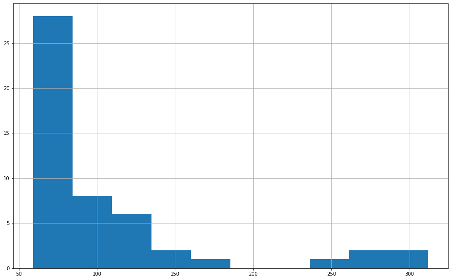

```python
print('Number of tweets distribution for the 50 most tweeting users:')
df.screen_name.value_counts()[:50].hist()
```

5- Identify duplicate tweets based on the 'text' field.

```python
print('Duplicate tweets:')
df[df.duplicated('text')]
```

```
Duplicate tweets:
```

|  | Unnamed: 0 | Unnamed: 0.1 | coordinates | country | created_at | device | entity_hashtags | entity_mentions | entity_type | entity_urls | id_str | in_reply_to_user_id | is_retweet | screen_name | text | tweet_location | user_followers | user_following | user_id | user_location |
| --- | --- | --- | --- | --- | --- | --- | --- | --- | --- | --- | --- | --- | --- | --- | --- | --- | --- | --- | --- | --- |
| 12 | 34658 | 34658 | NaN | NaN | 2020-03-03 02:49:47 | Twitter for Android | [] | ['NYGovCuomo'] | NaN | [] | 1234672290626859009 | NaN | True | NowItsOurTurn1 | RT @NYGovCuomo: BREAKING: I am announcing a new directive requiring NY health insurers to waive cost sharing associated with testing for #c… | NaN | 763 | 1106 | 1047932292537057280 | NaN |
| 14 | 34660 | 34660 | NaN | NaN | 2020-03-03 02:49:47 | Twitter Web App | [] | ['NYGovCuomo'] | NaN | [] | 1234672287103631361 | NaN | True | blinxeto | RT @NYGovCuomo: BREAKING: I am announcing a new directive requiring NY health insurers to waive cost sharing associated with testing for #c… | NaN | 97 | 50 | 1144799004972257287 | NaN |
| 15 | 34661 | 34661 | NaN | NaN | 2020-03-03 02:49:46 | Twitter for iPhone | [] | ['NYGovCuomo'] | NaN | [] | 1234672285929226240 | NaN | True | heyitsallcool | RT @NYGovCuomo: BREAKING: I am announcing a new directive requiring NY health insurers to waive cost sharing associated with testing for #c… | NaN | 592 | 552 | 4710791536 | NaN |
| 18 | 34664 | 34664 | NaN | NaN | 2020-03-03 02:49:46 | Twitter for Android | [] | ['shobey_edits'] | NaN | [] | 1234672284784185344 | NaN | True | luizywooya | RT @shobey_edits: sent a mail to marvel ent, regarding dogyul and dongpyo's fm asking about any update in-line with covid-19 and finally go… | NaN | 3723 | 3771 | 1197833978721341441 | \n\nᴿʸᵉᵒⁿˢᵉᵘⁿᵍ🍑ᵐᵘˡᶠᵃⁿᵈ🍕ᵉⁿᵍ/ⁱⁿᵈ |
| 19 | 34665 | 34665 | NaN | NaN | 2020-03-03 02:49:46 | Twitter for Android | [] | ['shobey_edits'] | NaN | [] | 1234672284448645120 | NaN | True | ljhuyeuye | RT @shobey_edits: sent a mail to marvel ent, regarding dogyul and dongpyo's fm asking about any update in-line with covid-19 and finally go… | NaN | 489 | 1152 | 420826863 | x98it |
| ... | ... | ... | ... | ... | ... | ... | ... | ... | ... | ... | ... | ... | ... | ... | ... | ... | ... | ... | ... | ... |
| 541788 | 1048570 | 1050544 | NaN | NaN | 2020-02-29 17:56:27 | Twitter for Android | ['COVID19'] | ['Laurie_Garrett'] | NaN | [] | 1233813296135987201 | NaN | True | Who_IsM | RT @Laurie_Garrett: If the US govt keeps billing Americans $1000s for evacuations and #COVID19 quarantine, people who are infected will hid… | NaN | 1937 | 4996 | 968640829 | Earth |
| 541789 | 1048571 | 1050545 | NaN | NaN | 2020-02-29 17:56:27 | Twitter for iPhone | ['coronavirus'] | ['tancredipalmeri'] | NaN | [] | 1233813295561355264 | NaN | True | orionmaggi | RT @tancredipalmeri: The #coronavirus cases in Italy: (accumulative count) Day1: 14cases/1dead Day2: 76/2 Day3: 153/3 Day4: 231/7 Day5: 37… | NaN | 162 | 587 | 794726696 | New England |
| 541790 | 1048572 | 1050546 | NaN | NaN | 2020-02-29 17:56:25 | Twitter for iPhone | [] | ['treasonstickers'] | NaN | [] | 1233813288930226176 | NaN | True | Peace_NH | RT @treasonstickers: FUN FACT: Donald Trump is the first President in US history to get impeached, botch a pandemic quarantine and cause a… | NaN | 594 | 434 | 2511294116 | New Hampshire |
| 541791 | 1048573 | 1050547 | NaN | NaN | 2020-02-29 17:56:25 | Twitter for iPhone | [] | ['washingtonpost'] | NaN | [] | 1233813288644792320 | NaN | True | avoidchaos | RT @washingtonpost: DHS employee told to report to work in Newark after China travel, in violation of coronavirus quarantine, complaints sa… | NaN | 766 | 518 | 1177196383 | Los Angeles, CA |
| 541792 | 1048574 | 1050548 | NaN | NaN | 2020-02-29 17:56:25 | Twitter for iPhone | [] | ['delta_su', 'bajas_k'] | NaN | [] | 1233813287852097538 | NaN | True | NewImproved9 | RT @delta_su: @bajas_k Maybe he is in self quarantine from his travels,to hold hands with leader of Iran.He disgusted Canadians as he bowed… | NaN | 3507 | 3591 | 944714037241114624 | British Columbia, Canada |

420992 rows × 20 columns

6- Remove duplicate tweets based on the 'text' field. How many tweets do you have now?

```python
df = df[~df.duplicated('text')]
```

```python
print('Current number of tweets: {}'.format(len(df)))
```

```
Current number of tweets: 120801
```

7- Replace all users names with the usrusr token. You need to write a regular expression that identify user names and use the replace method to replace it with the 'usrusr' token.

```python
df.text = df.text.replace(r'@\w+', 'usrusr', regex=True)
```

8- Replace all URLs with 'urlurl' token in the 'text' column.

```python
# URL pattern
urlp = r'''(?i)\b((?:https?:(?:/{1,3}|[a-z0-9%])|[a-z0-9.\-]+[.](?:com|net|org|edu|gov|mil|aero|asia|biz|cat|coop|info|int|jobs|mobi|museum|name|post|pro|tel|travel|xxx|ac|ad|ae|af|ag|ai|al|am|an|ao|aq|ar|as|at|au|aw|ax|az|ba|bb|bd|be|bf|bg|bh|bi|bj|bm|bn|bo|br|bs|bt|bv|bw|by|bz|ca|cc|cd|cf|cg|ch|ci|ck|cl|cm|cn|co|cr|cs|cu|cv|cx|cy|cz|dd|de|dj|dk|dm|do|dz|ec|ee|eg|eh|er|es|et|eu|fi|fj|fk|fm|fo|fr|ga|gb|gd|ge|gf|gg|gh|gi|gl|gm|gn|gp|gq|gr|gs|gt|gu|gw|gy|hk|hm|hn|hr|ht|hu|id|ie|il|im|in|io|iq|ir|is|it|je|jm|jo|jp|ke|kg|kh|ki|km|kn|kp|kr|kw|ky|kz|la|lb|lc|li|lk|lr|ls|lt|lu|lv|ly|ma|mc|md|me|mg|mh|mk|ml|mm|mn|mo|mp|mq|mr|ms|mt|mu|mv|mw|mx|my|mz|na|nc|ne|nf|ng|ni|nl|no|np|nr|nu|nz|om|pa|pe|pf|pg|ph|pk|pl|pm|pn|pr|ps|pt|pw|py|qa|re|ro|rs|ru|rw|sa|sb|sc|sd|se|sg|sh|si|sj|Ja|sk|sl|sm|sn|so|sr|ss|st|su|sv|sx|sy|sz|tc|td|tf|tg|th|tj|tk|tl|tm|tn|to|tp|tr|tt|tv|tw|tz|ua|ug|uk|us|uy|uz|va|vc|ve|vg|vi|vn|vu|wf|ws|ye|yt|yu|za|zm|zw)/)(?:[^\s()<>{}\[\]]+|\([^\s()]*?\([^\s()]+\)[^\s()]*?\)|\([^\s]+?\))+(?:\([^\s()]*?\([^\s()]+\)[^\s()]*?\)|\([^\s]+?\)|[^\s`!()\[\]{};:'".,<>?«»“”‘’])|(?:(?<!@)[a-z0-9]+(?:[.\-][a-z0-9]+)*[.](?:com|net|org|edu|gov|mil|aero|asia|biz|cat|coop|info|int|jobs|mobi|museum|name|post|pro|tel|travel|xxx|ac|ad|ae|af|ag|ai|al|am|an|ao|aq|ar|as|at|au|aw|ax|az|ba|bb|bd|be|bf|bg|bh|bi|bj|bm|bn|bo|br|bs|bt|bv|bw|by|bz|ca|cc|cd|cf|cg|ch|ci|ck|cl|cm|cn|co|cr|cs|cu|cv|cx|cy|cz|dd|de|dj|dk|dm|do|dz|ec|ee|eg|eh|er|es|et|eu|fi|fj|fk|fm|fo|fr|ga|gb|gd|ge|gf|gg|gh|gi|gl|gm|gn|gp|gq|gr|gs|gt|gu|gw|gy|hk|hm|hn|hr|ht|hu|id|ie|il|im|in|io|iq|ir|is|it|je|jm|jo|jp|ke|kg|kh|ki|km|kn|kp|kr|kw|ky|kz|la|lb|lc|li|lk|lr|ls|lt|lu|lv|ly|ma|mc|md|me|mg|mh|mk|ml|mm|mn|mo|mp|mq|mr|ms|mt|mu|mv|mw|mx|my|mz|na|nc|ne|nf|ng|ni|nl|no|np|nr|nu|nz|om|pa|pe|pf|pg|ph|pk|pl|pm|pn|pr|ps|pt|pw|py|qa|re|ro|rs|ru|rw|sa|sb|sc|sd|se|sg|sh|si|sj|Ja|sk|sl|sm|sn|so|sr|ss|st|su|sv|sx|sy|sz|tc|td|tf|tg|th|tj|tk|tl|tm|tn|to|tp|tr|tt|tv|tw|tz|ua|ug|uk|us|uy|uz|va|vc|ve|vg|vi|vn|vu|wf|ws|ye|yt|yu|za|zm|zw)\b/?(?!@)))'''
```

```python
df.text = df.text.replace(urlp, 'urlurl', regex=True)
```

9- If a tweet starts with "RT @", it is a retweet. Remove all retweets from the dataframe.

```python
df = df[~df.text.str.startswith('RT @')]
```

10- If the field is_retweet contains the value True, this tweet is a retweet as well. Remove those as well.

```python
df = df[df['is_retweet'] == False]
```

11- Check how many duplicate tweets are there. Remove them. How many tweets do you have now?

```python
print('Number of duplicated tweets: {}'.format(sum(df.duplicated('text'))))
```

```
Number of duplicated tweets: 8560
```

```python
# removing duplicate tweets
df = df[~df.duplicated('text')]
```

12- Plot a histogram of the text lengths. What is the length of the longest and the shortest tweets?

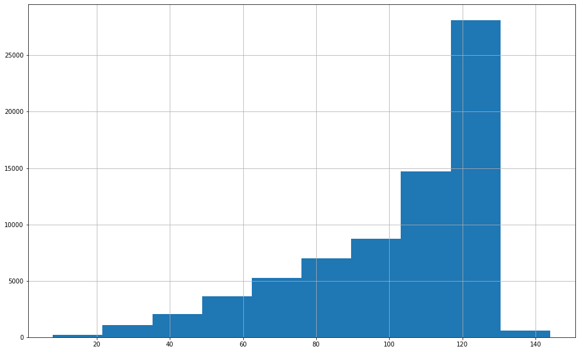

```python
# Histogram of text lengths
df.text.str.len().hist()
```

```python
print('Length of the longest tweet: {}'.format(df.text.str.len().max()))
```

```
Length of the longest tweet: 144
```

```python
print('Length of the shortest tweet: {}'.format(df.text.str.len().min()))
```

```
Length of the shortest tweet: 8
```

13- Calculate the average tweet length based on the 'text' field.

```python
print('Average tweet length: {}'.format(df.text.str.len().mean()))
```

```
Average tweet length: 101.68625830134222
```

14- Extract all words from the 'text' field and put them in a new column. The findall method and a regular expression to recognize words will help you.

```python
df['words'] = df.text.str.findall(r'[\w]+')
```

15- Identify the words that occur the most. The Counter object from collections will help you.

```python
from collections import Counter
import itertools
```

```python
# list of all words in all tweets
words = list(itertools.chain.from_iterable(df['words']))
```

```python
c = Counter(words)
```

```python
print('Words that occur the most:')
c.most_common(30)
```

```
Words that occur the most:
```

```
[('urlurl', 66936),
 ('usrusr', 44547),
 ('the', 39206),
 ('to', 26492),
 ('coronavirus', 21213),
 ('of', 20725),
 ('in', 17975),
 ('a', 16826),
 ('Coronavirus', 15472),
 ('is', 15067),
 ('and', 14751),
 ('for', 10417),
 ('s', 9845),
 ('I', 9663),
 ('on', 7775),
 ('The', 7191),
 ('that', 7102),
 ('you', 6737),
 ('are', 6654),
 ('it', 6436),
 ('t', 6318),
 ('19', 6190),
 ('from', 6036),
 ('quarantine', 5966),
 ('outbreak', 5680),
 ('with', 5562),
 ('this', 5423),
 ('have', 5172),
 ('be', 5103),
 ('COVID', 4840)]
```

16- How many of the words occur only once? List 100 of them. Provide tweets that contain these words.

```python
oneoccs = 0
for i in c.items():
    if i[1] == 1:
        oneoccs += 1
print('Number of words that occur only once: {}'.format(oneoccs))
```

```
Number of words that occur only once: 25200
```

```python
print('100 words that appeared only once: ')
c.most_common()[:-100-1:-1]
```

```
100 words that appeared only once:
```

```
[('kwanza', 1),
 ('Umeenda', 1),
 ('Lackla', 1),
 ('Hamburg', 1),
 ('screenplay', 1),
 ('Coul', 1),
 ('chinesecitizens', 1),
 ('REFUSED', 1),
 ('Day5', 1),
 ('Michiga', 1),
 ('andfoxnews', 1),
 ('floe', 1),
 ('fukks', 1),
 ('cooperating', 1),
 ('volunteering', 1),
 ('mammals', 1),
 ('CoronaChan', 1),
 ('Maj', 1),
 ('shorts', 1),
 ('IMH', 1),
 ('martiallaw', 1),
 ('Prepar', 1),
 ('85688', 1),
 ('Nooooooo', 1),
 ('hatfield2020', 1),
 ('Hatfield', 1),
 ('Toron', 1),
 ('Paramedics', 1),
 ('Professionally', 1),
 ('Flickr', 1),
 ('predisposition', 1),
 ('gddamn', 1),
 ('RuPaul', 1),
 ('mydude', 1),
 ('Panopticism', 1),
 ('Discipline', 1),
 ('chuckie', 1),
 ('dozing', 1),
 ('motherinlaw', 1),
 ('daggers', 1),
```

[output cut: 45 more lines]

```
 ('suns', 1),
 ('damp', 1),
 ('sucker', 1),
 ('103', 1),
 ('Spray', 1),
 ('CHANNEL', 1),
 ('FAUX', 1),
 ('foolishly', 1),
 ('TikTokviral', 1),
 ('OhNoIGotADisease', 1),
 ('lobbed', 1),
 ('iso', 1),
 ('Condolences', 1),
 ('50mil', 1),
 ('vaca', 1)]
```

```python
# The 100 words without their number of occurences
words1 = [i[0] for i in c.most_common()[:-100-1:-1]]
```

```python
# Tweets that contain any of the 100 words
df[[any(i in x for i in words1) for x in df['words']]]
```

|  | Unnamed: 0 | Unnamed: 0.1 | coordinates | country | created_at | device | entity_hashtags | entity_mentions | entity_type | entity_urls | ... | in_reply_to_user_id | is_retweet | screen_name | text | tweet_location | user_followers | user_following | user_id | user_location | words |
| --- | --- | --- | --- | --- | --- | --- | --- | --- | --- | --- | --- | --- | --- | --- | --- | --- | --- | --- | --- | --- | --- |
| 540590 | 1047372 | 1049346 | NaN | NaN | 2020-02-29 18:20:37 | Twitter for Android | [] | ['AdamSessler'] | NaN | ['twitter.com/i/web/status/1…'] | ... | 4.317048e+07 | False | rye_johnson | usrusr I mean. Round trip to Shanghai is cheap as hell and i have 4 weeks of vaca. Ill go there for 2 weeks a… urlurl | NaN | 48 | 166 | 602315561 | NaN | [usrusr, I, mean, Round, trip, to, Shanghai, is, cheap, as, hell, and, i, have, 4, weeks, of, vaca, Ill, go, there, for, 2, weeks, a, urlurl] |
| 540624 | 1047406 | 1049380 | NaN | NaN | 2020-02-29 18:19:58 | Twitter for iPhone | [] | ['m_higgy'] | NaN | ['twitter.com/i/web/status/1…'] | ... | 9.891109e+08 | False | fabrn01 | usrusr Honey where’ve you been? It’s not just a little cold. You don’t put 50mil on lockdown or quarantine people… urlurl | NaN | 69 | 249 | 408539541 | NaN | [usrusr, Honey, where, ve, you, been, It, s, not, just, a, little, cold, You, don, t, put, 50mil, on, lockdown, or, quarantine, people, urlurl] |
| 540632 | 1047414 | 1049388 | NaN | NaN | 2020-02-29 18:19:43 | Twitter for Android | [] | ['CityNews'] | NaN | [] | ... | 1.299322e+07 | False | mario_flyboy | usrusr Condolences to the family and friends. Stay safe. Quarantine. | NaN | 5 | 147 | 1225566489668878336 | NaN | [usrusr, Condolences, to, the, family, and, friends, Stay, safe, Quarantine] |
| 540654 | 1047436 | 1049410 | NaN | NaN | 2020-02-29 18:19:09 | Twitter Web App | [] | [] | NaN | ['twitter.com/i/web/status/1…'] | ... | 6.049049e+07 | False | andreavogt | The bad news here is the contagion is still in expansion. The good news is that 52% of the infected are in self-iso… urlurl | NaN | 4106 | 2669 | 60490488 | Italy / USA | [The, bad, news, here, is, the, contagion, is, still, in, expansion, The, good, news, is, that, 52, of, the, infected, are, in, self, iso, urlurl] |
| 540717 | 1047499 | 1049473 | NaN | NaN | 2020-02-29 18:17:47 | Twitter for Android | [] | ['JAMA_current'] | NaN | ['twitter.com/i/web/status/1…'] | ... | NaN | False | coopesdetat | Meantime, this just lobbed at usrusr "These findings suggest that at least a proportion of recovered patien… urlurl | NaN | 12593 | 5914 | 205546805 | amy.coopes at croakey.org | [Meantime, this, just, lobbed, at, usrusr, These, findings, suggest, that, at, least, a, proportion, of, recovered, patien, urlurl] |
| ... | ... | ... | ... | ... | ... | ... | ... | ... | ... | ... | ... | ... | ... | ... | ... | ... | ... | ... | ... | ... | ... |
| 541686 | 1048468 | 1050442 | NaN | NaN | 2020-02-29 17:58:28 | Twitter Web Client | [] | ['YouTube'] | NaN | ['youtu.be/_m_YZJDneW4'] | ... | NaN | False | PhilipBabb | Coronavirus Hits Europe, Italy Under Quarantine, ITS GETTING WORSE, Coul... urlurl via usrusr | NaN | 1197 | 3629 | 1371096672 | London, Ontario | [Coronavirus, Hits, Europe, Italy, Under, Quarantine, ITS, GETTING, WORSE, Coul, urlurl, via, usrusr] |
| 541689 | 1048471 | 1050445 | NaN | NaN | 2020-02-29 17:58:23 | Twitter for iPhone | ['WritingCommunity'] | [] | photo | [] | ... | NaN | False | improvperson | Please quarantine me CDC so that I can get this screenplay done.#WritingCommunity urlurl | NaN | 571 | 1375 | 240950737 | NaN | [Please, quarantine, me, CDC, so, that, I, can, get, this, screenplay, done, WritingCommunity, urlurl] |
| 541723 | 1048505 | 1050479 | NaN | NaN | 2020-02-29 17:57:42 | Twitter for Android | [] | ['AscotBlack'] | NaN | ['twitter.com/i/web/status/1…'] | ... | 1.225089e+18 | False | rtom098 | usrusr New case in Hamburg from Iran. Two weeks ago we out everyone coming back from China into 2 weeks quaran… urlurl | NaN | 9 | 119 | 2283393660 | NaN | [usrusr, New, case, in, Hamburg, from, Iran, Two, weeks, ago, we, out, everyone, coming, back, from, China, into, 2, weeks, quaran, urlurl] |
| 541763 | 1048545 | 1050519 | NaN | NaN | 2020-02-29 17:57:01 | Twitter for iPhone | [] | ['barbaraward235', 'HanianEmpress', 'cracraft_teresa', 'realDonaldTrump'] | NaN | ['twitter.com/i/web/status/1…'] | ... | 3.349130e+09 | False | LisaSeaman8 | usrusr usrusr usrusr usrusr We have 11 confirmed here in San Antonio at Lackla… urlurl | NaN | 388 | 396 | 1091848067354120192 | San Antonio, TX | [usrusr, usrusr, usrusr, usrusr, We, have, 11, confirmed, here, in, San, Antonio, at, Lackla, urlurl] |
| 541786 | 1048568 | 1050542 | NaN | Kenya | 2020-02-29 17:56:32 | Twitter for Android | [] | ['Mwirigi'] | NaN | [] | ... | 1.646364e+07 | False | mougendi | usrusr Umeenda self quarantine kwanza? | Nairobi, Kenya | 6873 | 3065 | 30274860 | Nairobi, Kenya | [usrusr, Umeenda, self, quarantine, kwanza] |

80 rows × 21 columns

17- Find the longest 100 words. List them.

```python
import numpy as np
```

```python
unique_words = list(set(words))
```

```python
# Lengths of all words
lens = [len(i) for i in unique_words]
```

```python
# Indices of sorted words by length
inds = np.argsort(lens)
```

```python
print('List of longest 100 words: ')
[unique_words[i] for i in inds[-100:]]
```

```
List of longest 100 words:
```

```
['staycalmanddrinkcorona',
 'satoshididnkillhimself',
 '5pmBatuanPSdistributed',
 'MakingCoronaVirusGreat',
 'BTSSalamiBitingFakeOut',
 '中国军事情报高级官员参与秘密生化武器细菌研究',
 'ArtificialIntelligence',
 'SabadoDeGanarFollowers',
 'nomasCuandoLesConviene',
 'IfTwitterEndedTomorrow',
 'destinationhandwashing',
 'energy_storage_devices',
 'IrancoverupCoronavirus',
 'coronavirusswitzerland',
 'TrudeauNotFitForOffice',
 'makeamericathinkharder',
 'CoronavirusResourceHub',
 'GetTheCoronavirusFACTS',
 'Entwicklungspolitische',
 'HandMarkedPaperBallots',
 'HealthAndHumanServices',
 'elementaryschoolteacher',
 'VoteBlueNoMatterWho2020',
 'المترجم_في_خدمة_المترجم',
 'fightinfectiousdiseases',
 'InternationalTravelNews',
 'DrHabib_Covid19_Updates',
 'IndiaHidingCoronaStrike',
 'CancelSpringBreakTravel',
 'HealthcareProfessionals',
 'MurderAtTheMusicFactory',
 'CoronavirusRepatriation',
 'answer_common_questions',
 'WorldHealthOrganization',
 'BiafraNotOneWithNigeria',
 'WorldHealthOrganisation',
 'BeforeWeHaveSexWeShould',
 'AmericaIsARudderlessShip',
 'coronavirusisournewenemy',
 'BTSWorldTour2020Canceled',
```

[output cut: 45 more lines]

```
 'StrategicWaterInfrastructureLab',
 'Paracetamoxyfrusebendroneomycin',
 '917c20aaf12d51beb966474940ac560b',
 '50a0f72b87265844b9b0badc718ef634',
 '30f33416763b5208957a2d4161c23a45',
 'cc397384a5b258bab403594f4edbb73b',
 '22dba8c1e94654caab56b9bb483f7e4a',
 'Wuhan_Coronavirus_Survival_Manual',
 'TacklingNationalSecurityChallenges',
 'Coronavirususrusrusrusrusrusrusrusr',
 'sleepingonthecouchoutsideherbedroom',
 'CommonGoldenDemocraticEqualityRegionIn',
 'ITBCancellationCouldHurtBalearicBusinesses',
 'Bahabdhsisjdhdhdhshsudhehsushahahahahhahahahahahaha',
 'governmentsof_Japan_italy_Iran_Irak_Palestina_Cisjordnia']
```

18- Find tweets that are all in upper case, such as "THIS IS A TWEET ALL UPPER CASE." in their 'text' field.

```python
print('Tweets that are all in upper case:')
df[df.text.str.isupper()]
```

```
Tweets that are all in upper case:
```

|  | Unnamed: 0 | Unnamed: 0.1 | coordinates | country | created_at | device | entity_hashtags | entity_mentions | entity_type | entity_urls | ... | in_reply_to_user_id | is_retweet | screen_name | text | tweet_location | user_followers | user_following | user_id | user_location | words |
| --- | --- | --- | --- | --- | --- | --- | --- | --- | --- | --- | --- | --- | --- | --- | --- | --- | --- | --- | --- | --- | --- |
| 2766 | 37412 | 37412 | NaN | NaN | 2020-03-03 02:33:07 | Tweetbot for iΟS | ['ブタゴリラに匹敵する強そうなあだ名'] | [] | NaN | [] | ... | NaN | False | GreenPentatonic | #ブタゴリラに匹敵する強そうなあだ名 COVID-19 | NaN | 545 | 550 | 1096838755 | 大衆居酒屋 | [ブタゴリラに匹敵する強そうなあだ名, COVID, 19] |
| 6759 | 41405 | 41405 | NaN | NaN | 2020-03-03 02:10:15 | Tweetbot for iΟS | [] | [] | NaN | [] | ... | NaN | False | riezzamahendra | COVID-19/PROJECT-THANOS. | NaN | 919 | 328 | 304288495 | Lalaland | [COVID, 19, PROJECT, THANOS] |
| 14240 | 48886 | 48886 | NaN | NaN | 2020-03-03 01:27:52 | Twitter Web App | [] | [] | NaN | [] | ... | NaN | False | category_tv | COVID-19 | NaN | 4 | 44 | 1181508176652324864 | NaN | [COVID, 19] |
| 31791 | 177652 | 178240 | NaN | NaN | 2020-02-29 12:06:20 | Twitter for Android | [] | [] | NaN | [] | ... | NaN | False | crudeoil1000 | IRAN HEALTH AUTHORITIES CONFIRMED 9 DEATHS FROM CORONAVIRUS COVID-19 IN 24 HOURS | NaN | 90 | 311 | 864510617448841220 | indian ocean arabian sea | [IRAN, HEALTH, AUTHORITIES, CONFIRMED, 9, DEATHS, FROM, CORONAVIRUS, COVID, 19, IN, 24, HOURS] |
| 32172 | 178033 | 178621 | NaN | NaN | 2020-02-29 12:05:58 | Twitter for Android | [] | [] | NaN | [] | ... | NaN | False | AboutikaR | QATAR ANNOUNCES FIRST CASE OF CORONAVIRUS INFECTION - QATAR NEWS AGENCY | NaN | 24 | 119 | 1083158344251117568 | NaN | [QATAR, ANNOUNCES, FIRST, CASE, OF, CORONAVIRUS, INFECTION, QATAR, NEWS, AGENCY] |
| 37925 | 183786 | 184374 | NaN | NaN | 2020-02-29 12:01:03 | Twitter for Android | [] | [] | NaN | [] | ... | NaN | False | crudeoil1000 | IRAN HEALTH AUTHORITIES CONFIRMED 295 FRESH CASES OF CORONAVIRUS COVID-19 | NaN | 90 | 311 | 864510617448841220 | indian ocean arabian sea | [IRAN, HEALTH, AUTHORITIES, CONFIRMED, 295, FRESH, CASES, OF, CORONAVIRUS, COVID, 19] |
| 49772 | 195633 | 196221 | NaN | NaN | 2020-02-29 11:50:41 | Twitter for Android | [] | [] | NaN | [] | ... | NaN | False | AdebayoGbekelo1 | *ANOTHER SYMPTOM OF CORONAVIRUS IS WHEN YOU THINK CHELSEA WILL BEAT BAYERN MUNICH IN GERMANY*😁😁🤣🤣🤣🤣🤣 | NaN | 27 | 308 | 1137868913423859713 | NaN | [ANOTHER, SYMPTOM, OF, CORONAVIRUS, IS, WHEN, YOU, THINK, CHELSEA, WILL, BEAT, BAYERN, MUNICH, IN, GERMANY] |
| 85634 | 231495 | 232083 | NaN | NaN | 2020-02-29 11:16:51 | Twitter for iPhone | [] | [] | NaN | [] | ... | NaN | False | beyuhright | SOMEOME JUST CALLED THE CORONAVIRUS A WORLD TOUR NONONONONONONO | NaN | 6734 | 4389 | 942455544 | ♡ ARIANA FOLLOWS ♡ | [SOMEOME, JUST, CALLED, THE, CORONAVIRUS, A, WORLD, TOUR, NONONONONONONO] |
| 114670 | 260531 | 261119 | NaN | NaN | 2020-02-29 10:46:07 | Twitter Web App | [] | [] | NaN | [] | ... | 3.320020e+09 | False | asngfnearyou | AND ITS NOT EVEN ABOUT THE CORONAVIRUS | NaN | 809 | 415 | 3320020368 | london | [AND, ITS, NOT, EVEN, ABOUT, THE, CORONAVIRUS] |
| 136274 | 282135 | 282723 | NaN | NaN | 2020-02-29 10:22:20 | Twitter for iPhone | [] | [] | NaN | [] | ... | NaN | False | Griff_Condon28 | FLORENCE STUDENTS BEING SENT BACK TO USA DUE TO CORONAVIRUS | NaN | 1176 | 1122 | 473504449 | 508 to 703 to 55 | [FLORENCE, STUDENTS, BEING, SENT, BACK, TO, USA, DUE, TO, CORONAVIRUS] |
| 147852 | 293713 | 294301 | NaN | NaN | 2020-02-29 10:09:35 | Twitter for Android | [] | [] | NaN | [] | ... | NaN | False | johaseulgi | I JUST WOKE UP WHATS WRONG WITH CHUNGHA WHY IS SHE TRENDING W CORONAVIRUS ????????? | NaN | 434 | 399 | 1102670221897359365 | NaN | [I, JUST, WOKE, UP, WHATS, WRONG, WITH, CHUNGHA, WHY, IS, SHE, TRENDING, W, CORONAVIRUS] |
| 163738 | 309599 | 310187 | NaN | NaN | 2020-02-29 09:52:06 | Twitter Web App | [] | [] | NaN | [] | ... | NaN | False | OgiehorO | MIGHTIEST GOD PLEASE FORGIVE YOUR CHILDREN FOR THEIR SINS AND ERADICATE CORONAVIRUS FROM PLANET EARTH.THE GLORY BELONGS TO U ONLY.AMEN.🌳🎄🌲⛪️ | NaN | 6 | 118 | 880419648189210624 | Benin city, Edo state | [MIGHTIEST, GOD, PLEASE, FORGIVE, YOUR, CHILDREN, FOR, THEIR, SINS, AND, ERADICATE, CORONAVIRUS, FROM, PLANET, EARTH, THE, GLORY, BELONGS, TO, U, ONLY, AMEN] |
| 164541 | 310402 | 310990 | NaN | NaN | 2020-02-29 09:51:14 | Breaking Market News | [] | [] | NaN | [] | ... | NaN | False | breakingmkts | PERSON WHO WAS INFECTED WITH THE DEADLY CORONAVIRUS IN OMAN HAS BEEN CURED, OMAN NEWS AGENCY REPORTS | NaN | 493 | 11 | 865624663841320960 | NaN | [PERSON, WHO, WAS, INFECTED, WITH, THE, DEADLY, CORONAVIRUS, IN, OMAN, HAS, BEEN, CURED, OMAN, NEWS, AGENCY, REPORTS] |
| 178521 | 324382 | 324970 | NaN | NaN | 2020-02-29 09:35:28 | Twitter for Android | [] | [] | NaN | [] | ... | NaN | False | kingsleybiafran | GOVERNMENT OF APC IN ZOOLOGICAL REPUBLIC OF NIGERIA IS WORSE THAN CORONAVIRUS FOR REAL | NaN | 1370 | 4996 | 724990372246593536 | Los Angeles, CA | [GOVERNMENT, OF, APC, IN, ZOOLOGICAL, REPUBLIC, OF, NIGERIA, IS, WORSE, THAN, CORONAVIRUS, FOR, REAL] |
| 189890 | 335751 | 336339 | NaN | NaN | 2020-02-29 09:22:17 | Twitter for iPhone | [] | [] | NaN | [] | ... | NaN | False | cashewbutters | GUYS LIKE FR HOW BAD IS THE CORONAVIRUS | NaN | 274 | 288 | 878084573451534336 | behide you | [GUYS, LIKE, FR, HOW, BAD, IS, THE, CORONAVIRUS] |
| 192894 | 338755 | 339343 | NaN | NaN | 2020-02-29 09:18:51 | Twitter for iPhone | [] | [] | NaN | [] | ... | NaN | False | asari_freedom | MY PRAYER TODAY IS FOR GOD NOT TO ALLOW CORONAVIRUS ENTER ANY NOTHERN STATE .. | NaN | 3679 | 1100 | 1427292392 | NaN | [MY, PRAYER, TODAY, IS, FOR, GOD, NOT, TO, ALLOW, CORONAVIRUS, ENTER, ANY, NOTHERN, STATE] |
| 204798 | 350659 | 351247 | NaN | NaN | 2020-02-29 09:05:09 | TweetDeck | [] | [] | NaN | [] | ... | NaN | False | zeroheddge | WASHINGTON STATE REPORTS 1 NEW CASE OF CORONAVIRUS | NaN | 163 | 0 | 954340891233259520 | NaN | [WASHINGTON, STATE, REPORTS, 1, NEW, CASE, OF, CORONAVIRUS] |
| 213565 | 359426 | 360014 | NaN | NaN | 2020-02-29 08:55:24 | Twitter for iPhone | [] | [] | NaN | [] | ... | NaN | False | sixfootslim | FUCK CORONAVIRUS FUCK CHINA MANE, I BEEN HAD ALLERGIES SINCE I WAS 8 😇🤓😎 🇨🇳 | NaN | 815 | 314 | 243883120 | Albuquerque, NM | [FUCK, CORONAVIRUS, FUCK, CHINA, MANE, I, BEEN, HAD, ALLERGIES, SINCE, I, WAS, 8] |
| 232470 | 378331 | 378919 | NaN | NaN | 2020-02-29 08:35:00 | Twitter for Android | [] | [] | NaN | [] | ... | NaN | False | crudeoil1000 | S.KOREAN AUTHORITIES REPORT 219 NEW CORONAVIRUS CASES, SHARP RISE TO 3,150 | NaN | 90 | 311 | 864510617448841220 | indian ocean arabian sea | [S, KOREAN, AUTHORITIES, REPORT, 219, NEW, CORONAVIRUS, CASES, SHARP, RISE, TO, 3, 150] |
| 253242 | 399103 | 399691 | NaN | NaN | 2020-02-29 08:14:34 | Twitter for iPhone | [] | [] | NaN | [] | ... | NaN | False | waahiyaaat | YOU MOTHERFUCKERS ARENT WORRY ABOUT CORONAVIRUS? | NaN | 51 | 62 | 1217398733001961472 | NaN | [YOU, MOTHERFUCKERS, ARENT, WORRY, ABOUT, CORONAVIRUS] |
| 256042 | 401903 | 402491 | NaN | NaN | 2020-02-29 08:12:01 | Breaking Market News | [] | [] | NaN | [] | ... | NaN | False | breakingmkts | S.KOREA REPORTS 219 NEW CORONAVIRUS CASES, BRINGS TOTAL TO 3,150 -YONHAP | NaN | 494 | 11 | 865624663841320960 | NaN | [S, KOREA, REPORTS, 219, NEW, CORONAVIRUS, CASES, BRINGS, TOTAL, TO, 3, 150, YONHAP] |
| 267074 | 412935 | 413523 | NaN | NaN | 2020-02-29 08:01:47 | Twitter for iPhone | [] | [] | NaN | [] | ... | NaN | False | sixtyfivegrain2 | DUMB DONALD THE CORONAVIRUS IS HERE IN OUR COMMUNITIES AS WE“ TWEET”. | NaN | 0 | 6 | 1233659199743127552 | NaN | [DUMB, DONALD, THE, CORONAVIRUS, IS, HERE, IN, OUR, COMMUNITIES, AS, WE, TWEET] |
| 275569 | 421430 | 422018 | NaN | NaN | 2020-02-29 07:53:31 | Twitter for Android | [] | [] | NaN | [] | ... | NaN | False | kdivies1 | DO NOT BELIEVE A SINGLE WORD OUT OF PENCE'S LYING MOUTH ABOUT THE CORONAVIRUS AMERICA. YOU KNOW THIS RIGHT? | NaN | 2462 | 2757 | 897571962897215488 | NaN | [DO, NOT, BELIEVE, A, SINGLE, WORD, OUT, OF, PENCE, S, LYING, MOUTH, ABOUT, THE, CORONAVIRUS, AMERICA, YOU, KNOW, THIS, RIGHT] |
| 311310 | 457171 | 457759 | NaN | NaN | 2020-02-29 07:15:03 | Tweetbot for iΟS | [] | [] | NaN | [] | ... | NaN | False | GypsyDanger_ | ........................ DOGS CAN CATCH THE CORONAVIRUS !!!!! | NaN | 1395 | 2461 | 62841008 | Shinra, Megacorp; Jaeger pilot | [DOGS, CAN, CATCH, THE, CORONAVIRUS] |
| 316213 | 462074 | 462662 | NaN | NaN | 2020-02-29 07:09:56 | Twitter for iPhone | [] | [] | NaN | [] | ... | NaN | False | usmanyusuf | DEADLY DISEASES ORIGINATE FROM CHINA. IN 1918 FLU PANDEMIC IN CHINA CLAIMED OVER 50MILLION PEOPLE WORLDWIDE. AND NOW CORONAVIRUS | NaN | 1153 | 2297 | 89894744 | Abuja in Nigeria | [DEADLY, DISEASES, ORIGINATE, FROM, CHINA, IN, 1918, FLU, PANDEMIC, IN, CHINA, CLAIMED, OVER, 50MILLION, PEOPLE, WORLDWIDE, AND, NOW, CORONAVIRUS] |
| 317692 | 463553 | 464141 | NaN | NaN | 2020-02-29 07:08:27 | Twitter for iPhone | [] | [] | NaN | [] | ... | NaN | False | GLOOMGIRLZ | CORONAVIRUS IS IN MOUNTAIN VIEW WHAT THE FUCK | NaN | 1234 | 1141 | 540459137 | Mountain View, CA | [CORONAVIRUS, IS, IN, MOUNTAIN, VIEW, WHAT, THE, FUCK] |
| 373478 | 771766 | 772453 | NaN | NaN | 2020-03-02 01:23:15 | prosquawk | [] | [] | NaN | [] | ... | NaN | False | ProSquawk | NATIONAL AUSTRALIA BANK ECONOMISTS SEE A RISK OF A 50BP CUT ON TUE. IN AN AGGRESSIVE RESPONSE TO THE CORONAVIRUS OUTBREAK. | NaN | 3 | 0 | 1198010039895777285 | On the Edge of News | [NATIONAL, AUSTRALIA, BANK, ECONOMISTS, SEE, A, RISK, OF, A, 50BP, CUT, ON, TUE, IN, AN, AGGRESSIVE, RESPONSE, TO, THE, CORONAVIRUS, OUTBREAK] |
| 373519 | 771807 | 772494 | NaN | NaN | 2020-03-02 01:22:53 | Twitter Web App | ['DEVELOPING'] | [] | NaN | [] | ... | NaN | False | ThatHansLee | #DEVELOPING: NAB ECONOMISTS SEE A RISK OF A 50BP CUT ON TUESDAY IN AN AGGRESSIVE RESPONSE TO THE CORONAVIRUS OUTBREAK - RTRS | NaN | 318 | 365 | 2545474686 | Downtown Sydney | [DEVELOPING, NAB, ECONOMISTS, SEE, A, RISK, OF, A, 50BP, CUT, ON, TUESDAY, IN, AN, AGGRESSIVE, RESPONSE, TO, THE, CORONAVIRUS, OUTBREAK, RTRS] |
| 373685 | 771973 | 772660 | NaN | NaN | 2020-03-02 01:21:23 | Breaking Market News | [] | [] | NaN | [] | ... | NaN | False | breakingmkts | NATIONAL AUSTRALIA BANK ECONOMISTS SEE A RISK OF A 50BP CUT ON TUESDAY IN AN AGGRESSIVE RESPONSE TO THE CORONAVIRUS OUTBREAK | NaN | 506 | 12 | 865624663841320960 | NaN | [NATIONAL, AUSTRALIA, BANK, ECONOMISTS, SEE, A, RISK, OF, A, 50BP, CUT, ON, TUESDAY, IN, AN, AGGRESSIVE, RESPONSE, TO, THE, CORONAVIRUS, OUTBREAK] |
| 376474 | 774762 | 775449 | NaN | NaN | 2020-03-02 00:58:52 | TweetDeck | [] | [] | NaN | [] | ... | NaN | False | RedboxWire | BOJ STATEMENT: MARKETS MAKING UNSTABLE MOVEMENTS DUE TO UNCERTAINTY OVER CORONAVIRUS OUTBREAK IMPACT ON ECONOMY | NaN | 8857 | 1734 | 1040665819187953664 | London, England | [BOJ, STATEMENT, MARKETS, MAKING, UNSTABLE, MOVEMENTS, DUE, TO, UNCERTAINTY, OVER, CORONAVIRUS, OUTBREAK, IMPACT, ON, ECONOMY] |
| 376761 | 775049 | 775736 | NaN | NaN | 2020-03-02 00:56:26 | prosquawk | [] | [] | NaN | [] | ... | NaN | False | ProSquawk | BOJ: MARKETS MAKING UNSTABLE MOVEMENTS DUE TO UNCERTAINTY OVER THE CORONAVIRUS OUTBREAK IMPACT ON THE ECONOMY. | NaN | 3 | 0 | 1198010039895777285 | On the Edge of News | [BOJ, MARKETS, MAKING, UNSTABLE, MOVEMENTS, DUE, TO, UNCERTAINTY, OVER, THE, CORONAVIRUS, OUTBREAK, IMPACT, ON, THE, ECONOMY] |
| 377825 | 776113 | 776800 | NaN | NaN | 2020-03-02 00:47:20 | prosquawk | [] | [] | NaN | [] | ... | NaN | False | ProSquawk | DEATH TOLL FROM CORONAVIRUS OUTBREAK IN CHINA'S HUBEI AT 2,803 AS OF END-MAR. 1ST. | NaN | 3 | 0 | 1198010039895777285 | On the Edge of News | [DEATH, TOLL, FROM, CORONAVIRUS, OUTBREAK, IN, CHINA, S, HUBEI, AT, 2, 803, AS, OF, END, MAR, 1ST] |
| 378903 | 777191 | 777878 | NaN | NaN | 2020-03-02 00:38:23 | Breaking Market News | [] | [] | NaN | [] | ... | NaN | False | breakingmkts | DEATH TOLL FROM CORONAVIRUS OUTBREAK IN CHINA'S HUBEI AT 2,803 AS OF END-MARCH 1 | NaN | 506 | 12 | 865624663841320960 | NaN | [DEATH, TOLL, FROM, CORONAVIRUS, OUTBREAK, IN, CHINA, S, HUBEI, AT, 2, 803, AS, OF, END, MARCH, 1] |
| 379772 | 778060 | 778747 | NaN | NaN | 2020-03-02 00:31:00 | Twitter Web App | [] | [] | NaN | [] | ... | NaN | False | PriapusIQ | 🇰🇷🧮 SOUTH KOREA IHS MARKIT FEB MANUFACTURING PMI AT 48.7 VS 49.8 IN JAN, SECTOR SHAKEN BY CORONAVIRUS OUTBREAK | NaN | 3605 | 264 | 1160506639046328321 | Newsletter Signup 👉 | [SOUTH, KOREA, IHS, MARKIT, FEB, MANUFACTURING, PMI, AT, 48, 7, VS, 49, 8, IN, JAN, SECTOR, SHAKEN, BY, CORONAVIRUS, OUTBREAK] |
| 513949 | 1020731 | 1022679 | NaN | NaN | 2020-03-01 05:05:13 | Twitter for iPhone | [] | [] | NaN | [] | ... | NaN | False | nyctophylluia | /BRUH WHEN UR FC IS UNDER QUARANTINE BC SHE ALMOST GOT THE CORONAVIRUS - | NaN | 123 | 168 | 1066123206430347267 | ¹⁷⁺ ———— 𝖮𝖯𝖤𝖭 𝖣𝖬𝖲. | [BRUH, WHEN, UR, FC, IS, UNDER, QUARANTINE, BC, SHE, ALMOST, GOT, THE, CORONAVIRUS] |
| 514341 | 1021123 | 1023071 | NaN | NaN | 2020-03-01 04:53:13 | Twitter for Android | [] | [] | NaN | [] | ... | NaN | False | jdmilesaway | CHUNG HA IS ON SELF QUARANTINE I WANT TO CRY TAKE CARE QUEEN I LOVE YOU SO MUCH 😔 | NaN | 166 | 119 | 902102911194238976 | NaN | [CHUNG, HA, IS, ON, SELF, QUARANTINE, I, WANT, TO, CRY, TAKE, CARE, QUEEN, I, LOVE, YOU, SO, MUCH] |
| 517540 | 1024322 | 1026275 | NaN | NaN | 2020-03-01 03:44:25 | Twitter Web App | [] | [] | NaN | [] | ... | 1.029442e+09 | False | jiggawutt | ☣️ QUARANTINE: ☣️GAMERS☣️ONLY☣️ | NaN | 42 | 138 | 1029441924 | INSIDE THE HOUSE | [QUARANTINE, GAMERS, ONLY] |
| 532034 | 1038816 | 1040785 | NaN | NaN | 2020-02-29 21:25:11 | Twitter Web App | [] | [] | NaN | [] | ... | NaN | False | Stockingtrader2 | QUARANTINE ALL NON WHITES NOW .. SEGR•GATION SAVES USA IS ONLY 40% WHITE THE WORLDS 9% WHITE | NaN | 1 | 12 | 1087062639384113152 | NaN | [QUARANTINE, ALL, NON, WHITES, NOW, SEGR, GATION, SAVES, USA, IS, ONLY, 40, WHITE, THE, WORLDS, 9, WHITE] |

38 rows × 21 columns

19- Identify the mostly occurring 50 hashtags.

```python
# Mostly occurring 50 hashtags
Counter(df['entity_hashtags']).most_common(50)
```

```
[('[]', 56289),
 ("['coronavirus']", 2372),
 ("['Coronavirus']", 938),
 ("['COVID19']", 664),
 ("['CoronaVirus']", 333),
 ("['coronavirus', 'COVID19']", 251),
 ("['COVID2019']", 118),
 ("['CoronavirusOutbreak']", 91),
 ("['GoogleAlerts']", 88),
 ("['COVIDー19']", 87),
 ("['COVID']", 83),
 ("['COVID19', 'coronavirus']", 81),
 ("['hoax']", 71),
 ("['RT']", 67),
 ("['covid19']", 63),
 ("['COVID19', 'Coronavirus']", 56),
 ("['coronavirus', 'COVAD19']", 55),
 ("['Coronavirus', 'COVID19']", 51),
 ("['SmartNews']", 50),
 ("['Iran']", 44),
 ("['Iran', 'coronavirus']", 43),
 ("['Coronavid19']", 42),
 ("['Covid_19']", 41),
 ("['CoronaVirusUpdates']", 40),
 ("['coronavirus', 'COVID2019']", 38),
 ("['coronavirus', 'covid19']", 37),
 ("['COVID2019', 'coronavirus']", 35),
 ("['coronavirus', 'COVIDー19']", 34),
 ("['BREAKING']", 33),
 ("['China']", 33),
 ("['CORONAVIRUS']", 33),
 ("['CoronaVirusUpdate']", 33),
 ("['Covid19']", 30),
 ("['CDC']", 28),
 ("['coronavirus', 'hoax']", 28),
 ("['COVID19US']", 27),
 ("['FoxNews']", 26),
 ("['COVID19Nigeria']", 24),
 ("['Coronavirus', 'COVID']", 21),
 ("['news']", 21),
 ("['Trump']", 21),
 ("['China', 'coronavirus']", 21),
 ("['coronavirusus']", 20),
 ("['coronavirus', 'China']", 20),
 ("['Topbuzz']", 20),
 ("['coronavirus', 'COVID2019', 'ChinaVirus']", 20),
 ("['TrumpLiesAboutCoronavirus']", 19),
 ("['CoronavirusKe']", 19),
 ("['SARSCoV2']", 18),
 ("['nCoV_2019']", 17)]
```

20- Export the final dataframe to csv and Excel files.

```python
# Exporting to CSV
df.to_csv('out.csv', index=False)
```

```python
# Exporting to Excel
df.to_excel('out.xlsx', index=False)
```

## Additional visualizations

```python
# converting string to datetime
df['created_at'] = pd.to_datetime(df['created_at'])
```

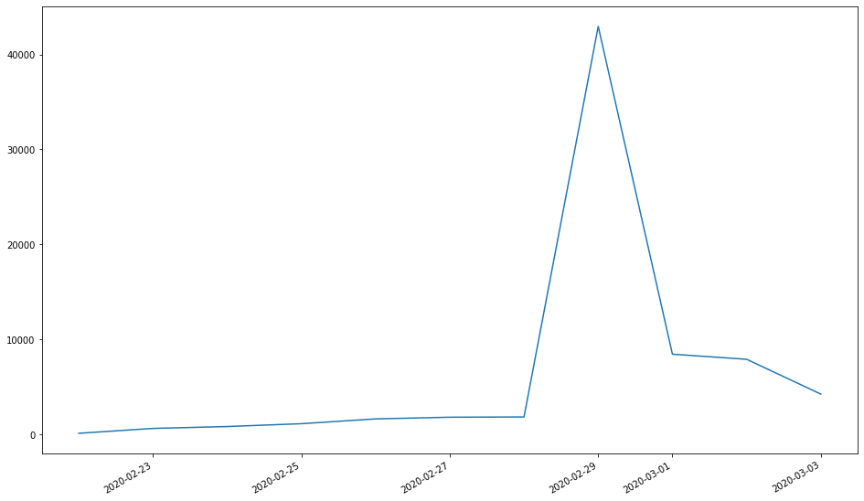

```python
# Tweet distribution over days
df['created_at'].dt.floor('d').value_counts().plot()
```

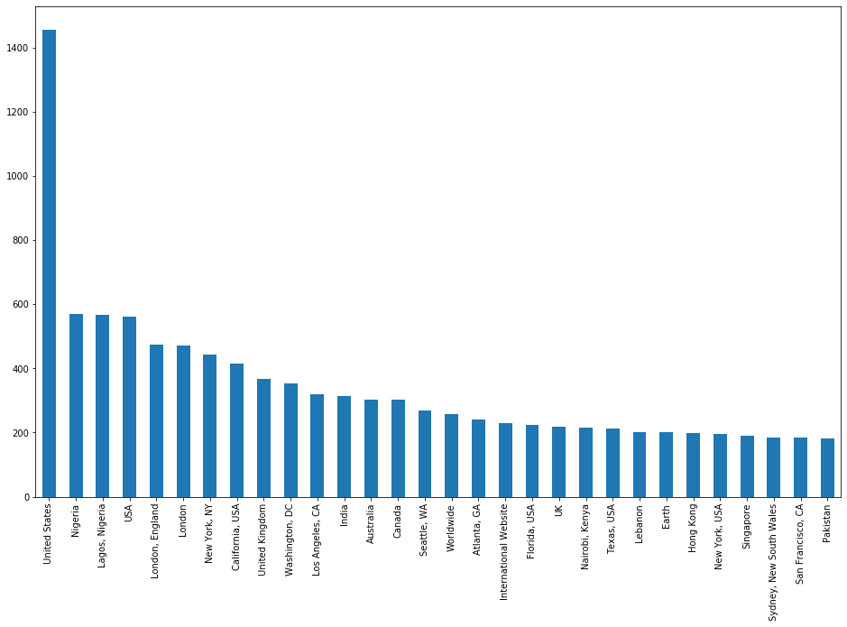

```python
# Tweet duistribution over user location
df['user_location'].value_counts()[:30].plot.bar()
```

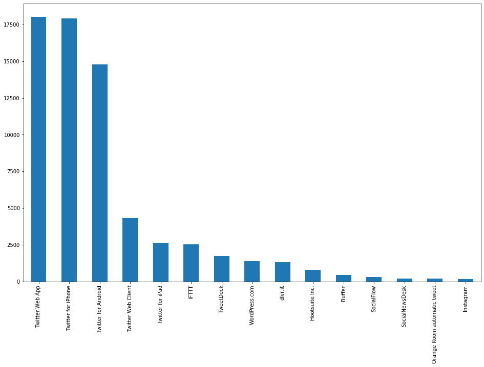

```python
# Tweet distribution over different devices
df['device'].value_counts()[:15].plot.bar()
```